# Final Project - Mushroom Classification

```python
import pandas as pd
import seaborn as sns
import matplotlib.pyplot as plt
import plotly.graph_objs as go
import plotly.express as px
```

## 1. Describe dataset

```python
# data from Kaggle: https://www.kaggle.com/uciml/mushroom-classification
mushroom = pd.read_csv("mushrooms.csv")
mushroom.head()
```

|  | class | cap-shape | cap-surface | cap-color | bruises | odor | gill-attachment | gill-spacing | gill-size | gill-color | ... | stalk-surface-below-ring | stalk-color-above-ring | stalk-color-below-ring | veil-type | veil-color | ring-number | ring-type | spore-print-color | population | habitat |
| --- | --- | --- | --- | --- | --- | --- | --- | --- | --- | --- | --- | --- | --- | --- | --- | --- | --- | --- | --- | --- | --- |
| 0 | p | x | s | n | t | p | f | c | n | k | ... | s | w | w | p | w | o | p | k | s | u |
| 1 | e | x | s | y | t | a | f | c | b | k | ... | s | w | w | p | w | o | p | n | n | g |
| 2 | e | b | s | w | t | l | f | c | b | n | ... | s | w | w | p | w | o | p | n | n | m |
| 3 | p | x | y | w | t | p | f | c | n | n | ... | s | w | w | p | w | o | p | k | s | u |
| 4 | e | x | s | g | f | n | f | w | b | k | ... | s | w | w | p | w | o | e | n | a | g |

5 rows × 23 columns

### 1.1 Data features

Attribute Information: (classes: edible=e, poisonous=p)

cap-shape: bell=b,conical=c,convex=x,flat=f, knobbed=k,sunken=s

cap-surface: fibrous=f,grooves=g,scaly=y,smooth=s

cap-color: brown=n,buff=b,cinnamon=c,gray=g,green=r,pink=p,purple=u,red=e,white=w,yellow=y

bruises: bruises=t,no=f

odor: almond=a,anise=l,creosote=c,fishy=y,foul=f,musty=m,none=n,pungent=p,spicy=s

gill-attachment: attached=a,descending=d,free=f,notched=n

gill-spacing: close=c,crowded=w,distant=d

gill-size: broad=b,narrow=n

gill-color: black=k,brown=n,buff=b,chocolate=h,gray=g,green=r,orange=o,pink=p,purple=u,red=e,white=w,yellow=y

stalk-shape: enlarging=e,tapering=t

stalk-root: bulbous=b,club=c,cup=u,equal=e,rhizomorphs=z,rooted=r,missing=?

stalk-surface-above-ring: fibrous=f,scaly=y,silky=k,smooth=s

stalk-surface-below-ring: fibrous=f,scaly=y,silky=k,smooth=s

stalk-color-above-ring: brown=n,buff=b,cinnamon=c,gray=g,orange=o,pink=p,red=e,white=w,yellow=y

stalk-color-below-ring: brown=n,buff=b,cinnamon=c,gray=g,orange=o,pink=p,red=e,white=w,yellow=y

veil-type: partial=p,universal=u

veil-color: brown=n,orange=o,white=w,yellow=y

ring-number: none=n,one=o,two=t

ring-type: cobwebby=c,evanescent=e,flaring=f,large=l,none=n,pendant=p,sheathing=s,zone=z

spore-print-color: black=k,brown=n,buff=b,chocolate=h,green=r,orange=o,purple=u,white=w,yellow=y

population: abundant=a,clustered=c,numerous=n,scattered=s,several=v,solitary=y

habitat: grasses=g,leaves=l,meadows=m,paths=p,urban=u,waste=w,woods=d

### 1.2 Data Cleasing

### 1.2.1 Checking null values

```python
mushroom.isnull().sum()
```

```
class                       0
cap-shape                   0
cap-surface                 0
cap-color                   0
bruises                     0
odor                        0
gill-attachment             0
gill-spacing                0
gill-size                   0
gill-color                  0
stalk-shape                 0
stalk-root                  0
stalk-surface-above-ring    0
stalk-surface-below-ring    0
stalk-color-above-ring      0
stalk-color-below-ring      0
veil-type                   0
veil-color                  0
ring-number                 0
ring-type                   0
spore-print-color           0
population                  0
habitat                     0
dtype: int64
```

There's no null values in the dataset, and the dataset are in a good quality. So I can do my analysis directly using the original file.

### 1.3 Exploratory Analysis

```python
mushroom.shape
```

```
(8124, 23)
```

```python
mushroom.describe()
```

|  | class | cap-shape | cap-surface | cap-color | bruises | odor | gill-attachment | gill-spacing | gill-size | gill-color | ... | stalk-surface-below-ring | stalk-color-above-ring | stalk-color-below-ring | veil-type | veil-color | ring-number | ring-type | spore-print-color | population | habitat |
| --- | --- | --- | --- | --- | --- | --- | --- | --- | --- | --- | --- | --- | --- | --- | --- | --- | --- | --- | --- | --- | --- |
| count | 8124 | 8124 | 8124 | 8124 | 8124 | 8124 | 8124 | 8124 | 8124 | 8124 | ... | 8124 | 8124 | 8124 | 8124 | 8124 | 8124 | 8124 | 8124 | 8124 | 8124 |
| unique | 2 | 6 | 4 | 10 | 2 | 9 | 2 | 2 | 2 | 12 | ... | 4 | 9 | 9 | 1 | 4 | 3 | 5 | 9 | 6 | 7 |
| top | e | x | y | n | f | n | f | c | b | b | ... | s | w | w | p | w | o | p | w | v | d |
| freq | 4208 | 3656 | 3244 | 2284 | 4748 | 3528 | 7914 | 6812 | 5612 | 1728 | ... | 4936 | 4464 | 4384 | 8124 | 7924 | 7488 | 3968 | 2388 | 4040 | 3148 |

4 rows × 23 columns

## 2. Visualization

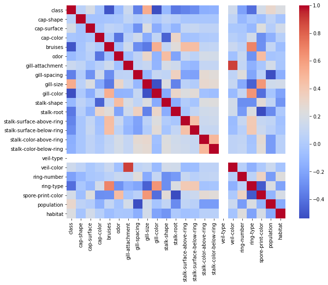

```python
from sklearn.preprocessing import LabelEncoder
vis = mushroom.copy()
le = LabelEncoder()
for col in vis.columns:
  vis[col] = le.fit_transform(vis[col])

import seaborn as sns
import matplotlib.pyplot as plt
plt.figure(figsize=(10,8))
ax = sns.heatmap(vis.corr(),cmap="coolwarm")
```

```python
import matplotlib.pylab as pylab
```

## 3. Data Processing

### 3.1 separating X and y

```python
X = mushroom.iloc[:,1:23]
y = mushroom.iloc[:,[0]]
```

### 3.2 Lable Encoding

```python
from sklearn.preprocessing import LabelEncoder
le = LabelEncoder()
for col in X.columns:
    X[col] = le.fit_transform(X[col])
Encoder_y=LabelEncoder()
y = Encoder_y.fit_transform(y)
X.head()
```

|  | cap-shape | cap-surface | cap-color | bruises | odor | gill-attachment | gill-spacing | gill-size | gill-color | stalk-shape | ... | stalk-surface-below-ring | stalk-color-above-ring | stalk-color-below-ring | veil-type | veil-color | ring-number | ring-type | spore-print-color | population | habitat |
| --- | --- | --- | --- | --- | --- | --- | --- | --- | --- | --- | --- | --- | --- | --- | --- | --- | --- | --- | --- | --- | --- |
| 0 | 5 | 2 | 4 | 1 | 6 | 1 | 0 | 1 | 4 | 0 | ... | 2 | 7 | 7 | 0 | 2 | 1 | 4 | 2 | 3 | 5 |
| 1 | 5 | 2 | 9 | 1 | 0 | 1 | 0 | 0 | 4 | 0 | ... | 2 | 7 | 7 | 0 | 2 | 1 | 4 | 3 | 2 | 1 |
| 2 | 0 | 2 | 8 | 1 | 3 | 1 | 0 | 0 | 5 | 0 | ... | 2 | 7 | 7 | 0 | 2 | 1 | 4 | 3 | 2 | 3 |
| 3 | 5 | 3 | 8 | 1 | 6 | 1 | 0 | 1 | 5 | 0 | ... | 2 | 7 | 7 | 0 | 2 | 1 | 4 | 2 | 3 | 5 |
| 4 | 5 | 2 | 3 | 0 | 5 | 1 | 1 | 0 | 4 | 1 | ... | 2 | 7 | 7 | 0 | 2 | 1 | 0 | 3 | 0 | 1 |

5 rows × 22 columns

```python
y
```

```
array([1, 0, 0, ..., 0, 1, 0])
```

##### NOTE: Poisonous = 1, Eatable = 0

### 3.3 Train-test Split

```python
from sklearn.model_selection import train_test_split
X_train, X_test, y_train, y_test = train_test_split(X, y, test_size=0.2, random_state=40)
```

### 3.3 Standard Scaling

```python
from sklearn.preprocessing import StandardScaler
sc = StandardScaler()

X_train = sc.fit_transform(X_train)
X_test = sc.transform(X_test)
```

## 4. Machine Learning Model

### 4.1 Logistic Regression and its accuracy

```python
from sklearn.linear_model import LogisticRegression
lr = LogisticRegression(penalty="none",solver="lbfgs")
lr.fit(X_train,y_train)
print("Train score:",lr.score(X_train,y_train))
print("Test score:", lr.score(X_test, y_test))
```

```
Train score: 0.9701492537313433
Test score: 0.9729230769230769
```

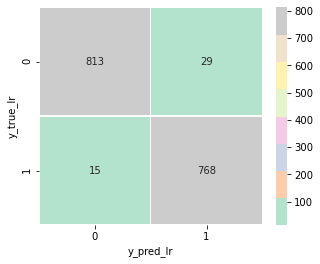

```python
from sklearn.metrics import confusion_matrix
y_pred_lr = lr.predict(X_test)
y_true_lr = y_test
cm = confusion_matrix(y_true_lr, y_pred_lr)
f, ax = plt.subplots(figsize =(5,4))
sns.heatmap(cm,annot = True,cmap="Pastel2",linewidths=0.5,fmt = ".0f",ax=ax)
plt.xlabel("y_pred_lr")
plt.ylabel("y_true_lr")
plt.show()
```

### 4.2 KNN Classifier and its accuracy

```python
from sklearn.neighbors import KNeighborsClassifier

knn = KNeighborsClassifier()
knn.fit(X_train,y_train)
print("Train score:",knn.score(X_train,y_train))
print("Test score:", knn.score(X_test, y_test))
```

```
Train score: 1.0
Test score: 1.0
```

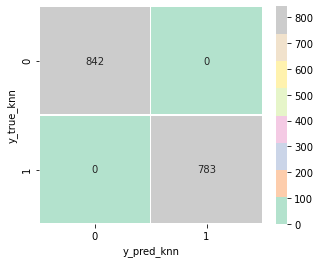

```python
from sklearn.metrics import confusion_matrix
y_pred_knn = knn.predict(X_test)
y_true_knn = y_test
cm = confusion_matrix(y_true_knn, y_pred_knn)
f, ax = plt.subplots(figsize =(5,4))
sns.heatmap(cm,annot = True,cmap="Pastel2",linewidths=0.5,fmt = ".0f",ax=ax)
plt.xlabel("y_pred_knn")
plt.ylabel("y_true_knn")
plt.show()
```

### 4.3 Naive Bayes and its accuracy

```python
from sklearn.naive_bayes import GaussianNB

nb = GaussianNB()
nb.fit(X_train,y_train)
print("Train score:",nb.score(X_train,y_train))
print("Test score:", nb.score(X_test, y_test))
```

```
Train score: 0.9213725188490537
Test score: 0.9163076923076923
```

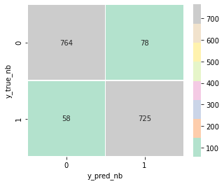

```python
from sklearn.metrics import confusion_matrix
y_pred_nb = nb.predict(X_test)
y_true_nb = y_test
cm = confusion_matrix(y_true_nb, y_pred_nb)
f, ax = plt.subplots(figsize =(5,4))
sns.heatmap(cm,annot = True,cmap="Pastel2",linewidths=0.5,fmt = ".0f",ax=ax)
plt.xlabel("y_pred_nb")
plt.ylabel("y_true_nb")
plt.show()
```

### 4.4 Support Vecor (SVC) Classification and its accuracy

```python
from sklearn.svm import SVC
svc = SVC(kernel='rbf',random_state=40)
svc.fit(X_train,y_train)
print("Train score:",svc.score(X_train,y_train))
print("Test score:", svc.score(X_test, y_test))
```

```
Train score: 1.0
Test score: 1.0
```

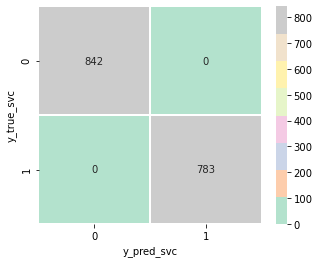

```python
from sklearn.metrics import confusion_matrix
y_pred_svc = svc.predict(X_test)
y_true_svc = y_test
cm = confusion_matrix(y_true_svc, y_pred_svc)
f, ax = plt.subplots(figsize =(5,4))
sns.heatmap(cm,annot = True,cmap="Pastel2",linewidths=0.5,fmt = ".0f",ax=ax)
plt.xlabel("y_pred_svc")
plt.ylabel("y_true_svc")
plt.show()
```

### 4.4 Deceision Tree Classification and its accuracy

```python
from sklearn.tree import DecisionTreeClassifier
dtc = DecisionTreeClassifier()
dtc.fit(X_train, y_train)
print("Train score:",dtc.score(X_train,y_train))
print("Test score:", dtc.score(X_test, y_test))
```

```
Train score: 1.0
Test score: 1.0
```

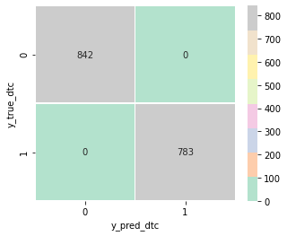

```python
from sklearn.metrics import confusion_matrix
y_pred_dtc = dtc.predict(X_test)
y_true_dtc = y_test
cm = confusion_matrix(y_true_dtc, y_pred_dtc)
f, ax = plt.subplots(figsize =(5,4))
sns.heatmap(cm,annot = True,cmap="Pastel2",linewidths=0.5,fmt = ".0f",ax=ax)
plt.xlabel("y_pred_dtc")
plt.ylabel("y_true_dtc")
plt.show()
```

### 4.5 Random Forest Classification and its accuracy

```python
from sklearn.ensemble import RandomForestClassifier
forest = RandomForestClassifier(max_depth=10,n_estimators=500, random_state=40,max_features=2)
forest.fit(X_train,y_train)
print("Train score:",forest.score(X_train,y_train))
print("Test score:", forest.score(X_test, y_test))
```

```
Train score: 1.0
Test score: 1.0
```

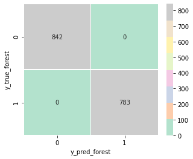

```python
from sklearn.metrics import confusion_matrix
y_pred_forest = forest.predict(X_test)
y_true_forest = y_test
cm = confusion_matrix(y_true_forest, y_pred_forest)
f, ax = plt.subplots(figsize =(5,4))
sns.heatmap(cm,annot = True,cmap="Pastel2",linewidths=0.5,fmt = ".0f",ax=ax)
plt.xlabel("y_pred_forest")
plt.ylabel("y_true_forest")
plt.show()
```

## 5. Results Overview

```python
from tabulate import tabulate
table = [["Model",'Train score','Test score'],
         ["Logistic Regression",0.9701,0.9730],
         ["Naive Bayes",0.9214,0.9163],
         ["Support Vecor (SVC) Classification",1.0,1.0],
         ["Deceision Tree Classification",1.0,1.0],
         ["Random Forest Classification",1.0,1.0]]
print(tabulate(table,headers="firstrow", tablefmt="fancy_grid"))
```

```
╒════════════════════════════════════╤═══════════════╤══════════════╕
│ Model                              │   Train score │   Test score │
╞════════════════════════════════════╪═══════════════╪══════════════╡
│ Logistic Regression                │        0.9701 │       0.973  │
├────────────────────────────────────┼───────────────┼──────────────┤
│ Naive Bayes                        │        0.9214 │       0.9163 │
├────────────────────────────────────┼───────────────┼──────────────┤
│ Support Vecor (SVC) Classification │        1      │       1      │
├────────────────────────────────────┼───────────────┼──────────────┤
│ Deceision Tree Classification      │        1      │       1      │
├────────────────────────────────────┼───────────────┼──────────────┤
│ Random Forest Classification       │        1      │       1      │
╘════════════════════════════════════╧═══════════════╧══════════════╛
```

##### With this information in mind, I would recommend people to use Support Vecor (SVC) Classification, Deceision Tree Classification, and Random Forest Classification model to do analysis on new data to better help with determine mushroom class.